# Part I - Exploring Ford GoBike System Data

## Introduction

This data set includes information about individual rides made in a bike-sharing system covering the greater San Francisco Bay area.

## Preliminary Wrangling

```python
# import all packages and set plots to be embedded inline
import numpy as np
import pandas as pd
import matplotlib.pyplot as plt
import seaborn as sb

%matplotlib inline
```

```python
df = pd.read_csv('201902-fordgobike-tripdata.csv')
```

```python
df.info()
```

```
<class 'pandas.core.frame.DataFrame'>
RangeIndex: 183412 entries, 0 to 183411
Data columns (total 16 columns):
duration_sec               183412 non-null int64
start_time                 183412 non-null object
end_time                   183412 non-null object
start_station_id           183215 non-null float64
start_station_name         183215 non-null object
start_station_latitude     183412 non-null float64
start_station_longitude    183412 non-null float64
end_station_id             183215 non-null float64
end_station_name           183215 non-null object
end_station_latitude       183412 non-null float64
end_station_longitude      183412 non-null float64
bike_id                    183412 non-null int64
user_type                  183412 non-null object
member_birth_year          175147 non-null float64
member_gender              175147 non-null object
bike_share_for_all_trip    183412 non-null object
dtypes: float64(7), int64(2), object(7)
memory usage: 22.4+ MB
```

```python
df.head()
```

|  | duration_sec | start_time | end_time | start_station_id | start_station_name | start_station_latitude | start_station_longitude | end_station_id | end_station_name | end_station_latitude | end_station_longitude | bike_id | user_type | member_birth_year | member_gender | bike_share_for_all_trip |
| --- | --- | --- | --- | --- | --- | --- | --- | --- | --- | --- | --- | --- | --- | --- | --- | --- |
| 0 | 52185 | 2019-02-28 17:32:10.1450 | 2019-03-01 08:01:55.9750 | 21.0 | Montgomery St BART Station (Market St at 2nd St) | 37.789625 | -122.400811 | 13.0 | Commercial St at Montgomery St | 37.794231 | -122.402923 | 4902 | Customer | 1984.0 | Male | No |
| 1 | 42521 | 2019-02-28 18:53:21.7890 | 2019-03-01 06:42:03.0560 | 23.0 | The Embarcadero at Steuart St | 37.791464 | -122.391034 | 81.0 | Berry St at 4th St | 37.775880 | -122.393170 | 2535 | Customer | NaN | NaN | No |
| 2 | 61854 | 2019-02-28 12:13:13.2180 | 2019-03-01 05:24:08.1460 | 86.0 | Market St at Dolores St | 37.769305 | -122.426826 | 3.0 | Powell St BART Station (Market St at 4th St) | 37.786375 | -122.404904 | 5905 | Customer | 1972.0 | Male | No |
| 3 | 36490 | 2019-02-28 17:54:26.0100 | 2019-03-01 04:02:36.8420 | 375.0 | Grove St at Masonic Ave | 37.774836 | -122.446546 | 70.0 | Central Ave at Fell St | 37.773311 | -122.444293 | 6638 | Subscriber | 1989.0 | Other | No |
| 4 | 1585 | 2019-02-28 23:54:18.5490 | 2019-03-01 00:20:44.0740 | 7.0 | Frank H Ogawa Plaza | 37.804562 | -122.271738 | 222.0 | 10th Ave at E 15th St | 37.792714 | -122.248780 | 4898 | Subscriber | 1974.0 | Male | Yes |

```python
# to get a new column of duration in minutes
df['duration_min'] = (df['duration_sec']/60).round(2)
```

```python
# to change the data type of start_time to datetime
df['start_time'] = pd.to_datetime(df['start_time'])
```

```python
# to change the data type of end_time to datetime
df['end_time'] = pd.to_datetime(df['end_time'])
```

```python
df['start_day'] = df['start_time'].dt.day_name()
```

```python
df['end_day'] = df['end_time'].dt.day_name()
```

```python
df['age'] = 2019 - df['member_birth_year']
```

```python
# to get the distance, I'd like to use the module geopy.
!pip install geopy
```

```
    100% |████████████████████████████████| 122kB 4.3MB/s ta 0:00:01
```

```python
import geopy.distance as dist
```

```python
# to get the column with tuple of start latitude and longitude
df['start_coords'] = df.apply(lambda x: (x[5],x[6]), axis = 1)
```

```python
# to get the column with tuple of end latitude and longitude
df['end_coords'] = df.apply(lambda x: (x[9],x[10]), axis = 1)
```

```python
# to get the distance by start and end coordinates
df['distance'] = df.apply(lambda x: dist.distance(x[-2],x[-1]).miles, axis = 1)
```

```python
# To get the start time in hour
df['start_hour'] = df['start_time'].apply(lambda x: x.hour)
```

```python
df.head()
```

|  | duration_sec | start_time | end_time | start_station_id | start_station_name | start_station_latitude | start_station_longitude | end_station_id | end_station_name | end_station_latitude | ... | member_gender | bike_share_for_all_trip | duration_min | start_day | end_day | age | start_coords | end_coords | distance | start_hour |
| --- | --- | --- | --- | --- | --- | --- | --- | --- | --- | --- | --- | --- | --- | --- | --- | --- | --- | --- | --- | --- | --- |
| 0 | 52185 | 2019-02-28 17:32:10.145 | 2019-03-01 08:01:55.975 | 21.0 | Montgomery St BART Station (Market St at 2nd St) | 37.789625 | -122.400811 | 13.0 | Commercial St at Montgomery St | 37.794231 | ... | Male | No | 869.75 | Thursday | Friday | 35.0 | (37.7896254, -122.400811) | (37.794230999999996, -122.402923) | 0.338015 | 17 |
| 1 | 42521 | 2019-02-28 18:53:21.789 | 2019-03-01 06:42:03.056 | 23.0 | The Embarcadero at Steuart St | 37.791464 | -122.391034 | 81.0 | Berry St at 4th St | 37.775880 | ... | NaN | No | 708.68 | Thursday | Friday | NaN | (37.791464000000005, -122.391034) | (37.77588, -122.39317) | 1.081130 | 18 |
| 2 | 61854 | 2019-02-28 12:13:13.218 | 2019-03-01 05:24:08.146 | 86.0 | Market St at Dolores St | 37.769305 | -122.426826 | 3.0 | Powell St BART Station (Market St at 4th St) | 37.786375 | ... | Male | No | 1030.90 | Thursday | Friday | 47.0 | (37.76930529999999, -122.4268256) | (37.78637526861584, -122.40490436553955) | 1.681051 | 12 |
| 3 | 36490 | 2019-02-28 17:54:26.010 | 2019-03-01 04:02:36.842 | 375.0 | Grove St at Masonic Ave | 37.774836 | -122.446546 | 70.0 | Central Ave at Fell St | 37.773311 | ... | Other | No | 608.17 | Thursday | Friday | 30.0 | (37.77483629413345, -122.44654566049576) | (37.77331087889723, -122.44429260492323) | 0.162113 | 17 |
| 4 | 1585 | 2019-02-28 23:54:18.549 | 2019-03-01 00:20:44.074 | 7.0 | Frank H Ogawa Plaza | 37.804562 | -122.271738 | 222.0 | 10th Ave at E 15th St | 37.792714 | ... | Male | Yes | 26.42 | Thursday | Friday | 45.0 | (37.8045623549303, -122.27173805236816) | (37.7927143, -122.24877959999999) | 1.498758 | 23 |

5 rows × 24 columns

```python
df['weekend'] = df.apply(lambda x: 'weekday' if x['start_day'] in ['Monday', 'Tuesday', 'Wednesday', 'Thursday', 'Friday'] else 'weekend', axis = 1)
```

```python
df.info()
```

```
<class 'pandas.core.frame.DataFrame'>
RangeIndex: 183412 entries, 0 to 183411
Data columns (total 25 columns):
duration_sec               183412 non-null int64
start_time                 183412 non-null datetime64[ns]
end_time                   183412 non-null datetime64[ns]
start_station_id           183215 non-null float64
start_station_name         183215 non-null object
start_station_latitude     183412 non-null float64
start_station_longitude    183412 non-null float64
end_station_id             183215 non-null float64
end_station_name           183215 non-null object
end_station_latitude       183412 non-null float64
end_station_longitude      183412 non-null float64
bike_id                    183412 non-null int64
user_type                  183412 non-null object
member_birth_year          175147 non-null float64
member_gender              175147 non-null object
bike_share_for_all_trip    183412 non-null object
duration_min               183412 non-null float64
start_day                  183412 non-null object
end_day                    183412 non-null object
age                        175147 non-null float64
start_coords               183412 non-null object
end_coords                 183412 non-null object
distance                   183412 non-null float64
start_hour                 183412 non-null int64
weekend                    183412 non-null object
dtypes: datetime64[ns](2), float64(10), int64(3), object(10)
memory usage: 35.0+ MB
```

### What is the structure of your dataset?

There are 183,412 bike trips in the dataset with 16 columns of information about each trip (duration_sec, start_time, end_time, start_station_id,start_station_name, start_station_latitude, start_station_longitude, end_station_id, end_station_name, end_station_latitude, end_station_longitude, bike_id, user_type, member_birth_year, member_gender, bike_share_for_all_trip). Most variables regarding the trips are numeric in nature, but there are also variables about the riders.

### What is/are the main feature(s) of interest in your dataset?

I'd like to see how long the average trip takes. How user types and gender would affect the riding behaviour. How age would affect the riding behaviour. How weekdays and weekends riding activities would differ. And finally the top 10 starting and ending spots during weekdays and weekends respectively.

### What features in the dataset do you think will help support your investigation into your feature(s) of interest?

I expect duration is the indicator of how long each ride takes. Features like user type, member gender, member birth year, and some new columns like duration_min (in minutes), age of users, distance calculated by coordinates, start_hour from start_time, start day and weekday/weekend, would help my investigation.

## Univariate Exploration

The first variable I look at is 'duration_min', which is the duration of the trip in minutes.

```python
df['duration_min'].describe()
```

```
count    183412.000000
mean         12.101301
std          29.906501
min           1.020000
25%           5.420000
50%           8.570000
75%          13.270000
max        1424.070000
Name: duration_min, dtype: float64
```

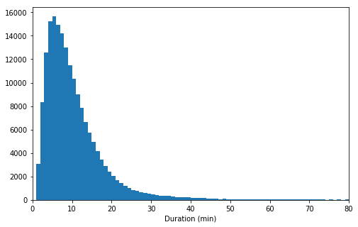

```python
# plotting duration in minutes on a standard scale
bins = np.arange(0, 1450, 1)

plt.figure(figsize = [8, 5])
plt.hist(data = df, x = 'duration_min', bins = bins)
plt.xlabel('Duration (min)')
plt.xlim(0, 80)
plt.show()
```

```python
np.log10(df['duration_min'].describe())
```

```
count    5.263428
mean     1.082832
std      1.475766
min      0.008600
25%      0.733999
50%      0.932981
75%      1.122871
max      3.153531
Name: duration_min, dtype: float64
```

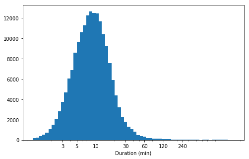

```python
# there's a long tail in the distribution, so let's put it on a log scale instead
log_binsize = 0.05
bins = 10 ** np.arange(0, np.log10(df['duration_min'].max())+log_binsize, log_binsize)

plt.figure(figsize = [8, 5])
plt.hist(data = df, x = 'duration_min', bins = bins)
plt.xscale('log')
plt.xticks([3, 5, 10, 30, 60, 120, 240], [3, 5, 10, 30, 60, 120, 240])
plt.xlabel('Duration (min)')
plt.show()
```

Duration in minutes has a long-tailed distribution, with most of the riders riding for around 10 minutes, and few over 30 minutes. When plotted on a log-scale, the price distribution looks unimodal, with one peak between 5 to 15 minutes.

Next, I'd like to look at user type.

```python
user_type = df['user_type'].value_counts()
```

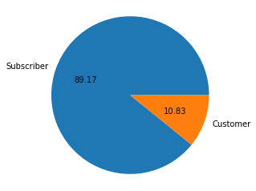

```python
plt.pie(user_type, labels = user_type.index, autopct='%.2f')
plt.axis('square');
```

89.17% of users are subsribers, while 10.83% of them are normal customers. It means most of the users bought packages (daily package, monthly package and annual package)

Next I'll move on to variable 'member_gender'.

```python
gender = df['member_gender'].value_counts()
```

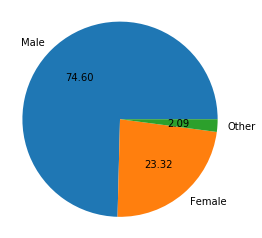

```python
plt.pie(gender, labels = gender.index, autopct='%.2f')
plt.axis('square');
```

74.60% of the users are males, while 23.32% of them are females. It means most of the users are males.

Next I'll move on to users' age.

```python
# There are some data that has no information on users' age.
no_age = df.query('age == "Nan"')
```

```python
no_age_index = no_age.index
```

```python
# to prepare a dataframe with only useful information in the column 'age'
df_age = df.drop(no_age_index, axis = 0)
```

```python
df_age['age'].describe()
```

```
count    175147.000000
mean         34.193563
std          10.116689
min          18.000000
25%          27.000000
50%          32.000000
75%          39.000000
max         141.000000
Name: age, dtype: float64
```

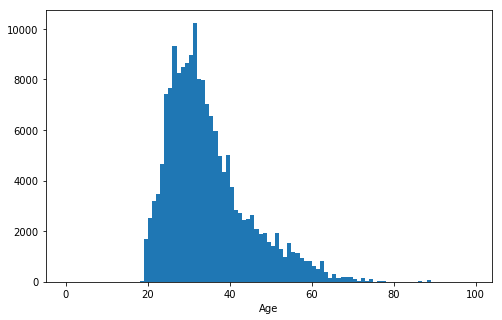

```python
bins = np.arange(0, 100, 1)

plt.figure(figsize = [8, 5])
plt.hist(data = df_age, x = 'age', bins = bins)
plt.xlabel('Age')
plt.show()
```

```python
np.log10(df_age['age'].describe())
```

```
count    5.243403
mean     1.533944
std      1.005038
min      1.255273
25%      1.431364
50%      1.505150
75%      1.591065
max      2.149219
Name: age, dtype: float64
```

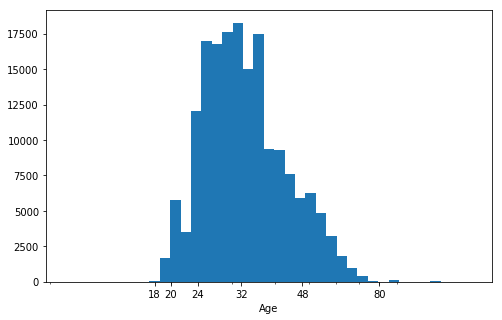

```python
# there's a long tail in the distribution, so let's put it on a log scale instead
log_binsize = 0.03
bins = 10 ** np.arange(1, np.log10(df_age['age'].max())+log_binsize, log_binsize)

plt.figure(figsize = [8, 5])
plt.hist(data = df_age, x = 'age', bins = bins)
plt.xscale('log')
plt.xticks([18, 20, 24, 32, 48, 80], [18, 20, 24, 32, 48, 80])
plt.xlabel('Age')
plt.show()
```

Age has a long-tailed distribution, with most of the riders at the age of 24 - 40. When plotted on a log-scale, the age distribution looks unimodal, with one peak between 24 - 38 years old.

Next up, I will look into the variable start_day.

```python
# define mycountplot so we can use it for sb.countplot
def mycountplot(df, x, hue=None, color=None, palette=None, order=None, fig=True):
    if fig:
        plt.figure(figsize = [14, 6])

    sb.countplot(data = df, x = x, hue = hue, color = color, palette = palette, order = order)
    plt.title(f'''Distribution of {x} {'by' if hue else ''} {hue if hue else ''}'''.title(), fontsize = 14, weight = 'bold')
    plt.xlabel(x.title(), fontsize = 10, weight = 'bold')
    plt.ylabel('Frequency', fontsize = 10, weight = 'bold')
```

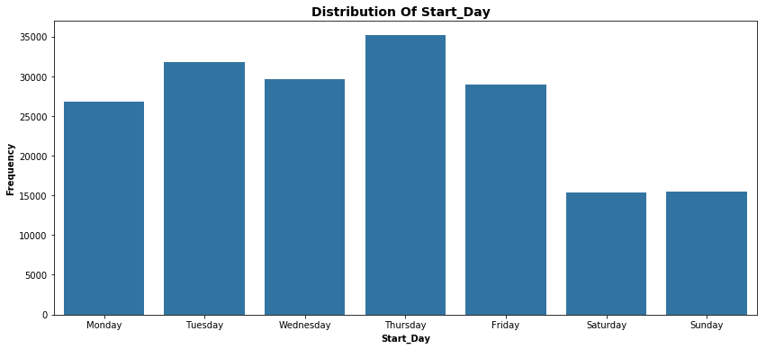

```python
mycountplot(df, 'start_day', color = sb.color_palette()[0], order = day_order)
```

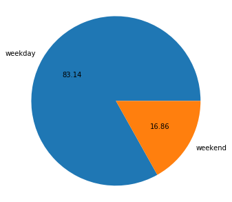

```python
weekend = df['weekend'].value_counts()

plt.figure(figsize = (8,5))
plt.pie(weekend, labels = weekend.index, autopct='%.2f')
plt.axis('square');
```

83.14% of users ride on weekdays.

Next I will move on to time of day.

```python
df['start_hour'].value_counts()
```

```
17    21864
8     21056
18    16827
9     15903
16    14169
7     10614
19     9881
15     9174
12     8724
13     8551
10     8364
14     8152
11     7884
20     6482
21     4561
6      3485
22     2916
23     1646
0       925
5       896
1       548
2       381
4       235
3       174
Name: start_hour, dtype: int64
```

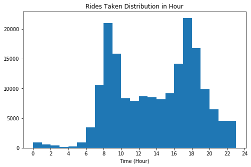

```python
bins = np.arange(0, 24, 1)

plt.figure(figsize = [8, 5])
plt.hist(data = df, x = 'start_hour', bins = bins)
plt.xlabel('Time (Hour)')
plt.xticks([0, 2, 4, 6, 8, 10, 12, 14, 16, 18, 20, 22, 24], [0, 2, 4, 6, 8, 10, 12, 14, 16, 18, 20, 22, 24])
plt.title('Rides Taken Distribution in Hour')
plt.show()
```

There are two peaks in a day. Most users ride from 8 - 10, and 16 - 20, which are the usual time people get to work and go home.

Next I will move on to distance.

```python
no_distance_ind = df.query('distance == 0').index
```

```python
df_distance = df.drop(no_distance_ind, axis = 0)
```

```python
df['distance'].describe()
```

```
count    183412.000000
mean          1.050462
std           0.681742
min           0.000000
25%           0.565309
50%           0.888503
75%           1.383277
max          43.164157
Name: distance, dtype: float64
```

```python
df_distance_log = df.query('distance != 0')
```

```python
np.log10(df_distance_log['distance'].describe())
```

```
count    5.254142
mean     0.030666
std     -0.173175
min     -2.082567
25%     -0.232732
50%     -0.042743
75%      0.146168
max      1.635123
Name: distance, dtype: float64
```

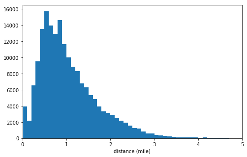

```python
bins = np.arange(0, 8, 0.1)

plt.figure(figsize = [8, 5])
plt.hist(data = df, x = 'distance', bins = bins)
plt.xlabel('distance (mile)')
plt.xlim(0, 5)
plt.show()
```

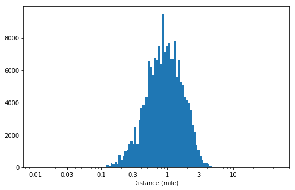

```python
# there's a long tail in the distribution, so let's put it on a log scale instead

log_binsize = 0.03
bins = 10 ** np.arange(-2, np.log10(df_age['distance'].max())+log_binsize, log_binsize)

plt.figure(figsize = [8, 5])
plt.hist(data = df_distance_log, x = 'distance', bins = bins)
plt.xscale('log')
plt.xticks([0.01, 0.03, 0.1, 0.3, 1, 3, 10], [0.01, 0.03, 0.1, 0.3, 1, 3, 10])
plt.xlabel('Distance (mile)')
plt.show()
```

Distance has a long-tailed distribution. When plotted on a log-scale, the distance distribution looks unimodal, with one peak between 0.5 to 2 miles.

### Discuss the distribution(s) of your variable(s) of interest. Were there any unusual points? Did you need to perform any transformations?

The duration (in minutes) has a long range of values, so I have used a log transformation. It then looks unimodal, with one peak between 5 - 15 minutes.

The age also has a long range of values, so I have used a log transformation again. It looks unimodal with one peak between 24 - 38 years old. I have also cleaned the data that contains "NaN".

### Of the features you investigated, were there any unusual distributions? Did you perform any operations on the data to tidy, adjust, or change the form of the data? If so, why did you do this?

When plotting distance in miles and duration in minutes, there are some outliers. So I used plt.xlim to limit the range we can see from the plot.

## Bivariate Exploration

```python
df.info()
```

```
<class 'pandas.core.frame.DataFrame'>
RangeIndex: 183412 entries, 0 to 183411
Data columns (total 25 columns):
duration_sec               183412 non-null int64
start_time                 183412 non-null datetime64[ns]
end_time                   183412 non-null datetime64[ns]
start_station_id           183215 non-null float64
start_station_name         183215 non-null object
start_station_latitude     183412 non-null float64
start_station_longitude    183412 non-null float64
end_station_id             183215 non-null float64
end_station_name           183215 non-null object
end_station_latitude       183412 non-null float64
end_station_longitude      183412 non-null float64
bike_id                    183412 non-null int64
user_type                  183412 non-null object
member_birth_year          175147 non-null float64
member_gender              175147 non-null object
bike_share_for_all_trip    183412 non-null object
duration_min               183412 non-null float64
start_day                  183412 non-null object
end_day                    183412 non-null object
age                        175147 non-null float64
start_coords               183412 non-null object
end_coords                 183412 non-null object
distance                   183412 non-null float64
start_hour                 183412 non-null int64
weekend                    183412 non-null object
dtypes: datetime64[ns](2), float64(10), int64(3), object(10)
memory usage: 35.0+ MB
```

```python
df.head()
```

|  | duration_sec | start_time | end_time | start_station_id | start_station_name | start_station_latitude | start_station_longitude | end_station_id | end_station_name | end_station_latitude | ... | bike_share_for_all_trip | duration_min | start_day | end_day | age | start_coords | end_coords | distance | start_hour | weekend |
| --- | --- | --- | --- | --- | --- | --- | --- | --- | --- | --- | --- | --- | --- | --- | --- | --- | --- | --- | --- | --- | --- |
| 0 | 52185 | 2019-02-28 17:32:10.145 | 2019-03-01 08:01:55.975 | 21.0 | Montgomery St BART Station (Market St at 2nd St) | 37.789625 | -122.400811 | 13.0 | Commercial St at Montgomery St | 37.794231 | ... | No | 869.75 | Thursday | Friday | 35.0 | (37.7896254, -122.400811) | (37.794230999999996, -122.402923) | 0.338015 | 17 | weekday |
| 1 | 42521 | 2019-02-28 18:53:21.789 | 2019-03-01 06:42:03.056 | 23.0 | The Embarcadero at Steuart St | 37.791464 | -122.391034 | 81.0 | Berry St at 4th St | 37.775880 | ... | No | 708.68 | Thursday | Friday | NaN | (37.791464000000005, -122.391034) | (37.77588, -122.39317) | 1.081130 | 18 | weekday |
| 2 | 61854 | 2019-02-28 12:13:13.218 | 2019-03-01 05:24:08.146 | 86.0 | Market St at Dolores St | 37.769305 | -122.426826 | 3.0 | Powell St BART Station (Market St at 4th St) | 37.786375 | ... | No | 1030.90 | Thursday | Friday | 47.0 | (37.76930529999999, -122.4268256) | (37.78637526861584, -122.40490436553955) | 1.681051 | 12 | weekday |
| 3 | 36490 | 2019-02-28 17:54:26.010 | 2019-03-01 04:02:36.842 | 375.0 | Grove St at Masonic Ave | 37.774836 | -122.446546 | 70.0 | Central Ave at Fell St | 37.773311 | ... | No | 608.17 | Thursday | Friday | 30.0 | (37.77483629413345, -122.44654566049576) | (37.77331087889723, -122.44429260492323) | 0.162113 | 17 | weekday |
| 4 | 1585 | 2019-02-28 23:54:18.549 | 2019-03-01 00:20:44.074 | 7.0 | Frank H Ogawa Plaza | 37.804562 | -122.271738 | 222.0 | 10th Ave at E 15th St | 37.792714 | ... | Yes | 26.42 | Thursday | Friday | 45.0 | (37.8045623549303, -122.27173805236816) | (37.7927143, -122.24877959999999) | 1.498758 | 23 | weekday |

5 rows × 25 columns

```python
numeric_vars = ['duration_min', 'age', 'distance']
categoric_vars = ['start_day', 'start_hour', 'member_gender', 'user_type']
```

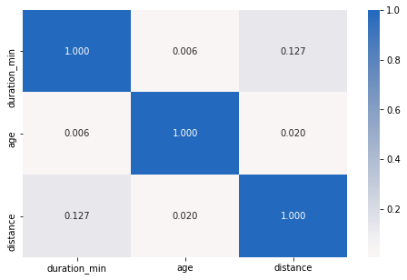

```python
# correlation plot
plt.figure(figsize = [8, 5])
sb.heatmap(df[numeric_vars].corr(), annot = True, fmt = '.3f',
           cmap = 'vlag_r', center = 0)
plt.show()
```

```python
# plot matrix of all numeric features

df_1 = df.query('age != "Nan"')
```

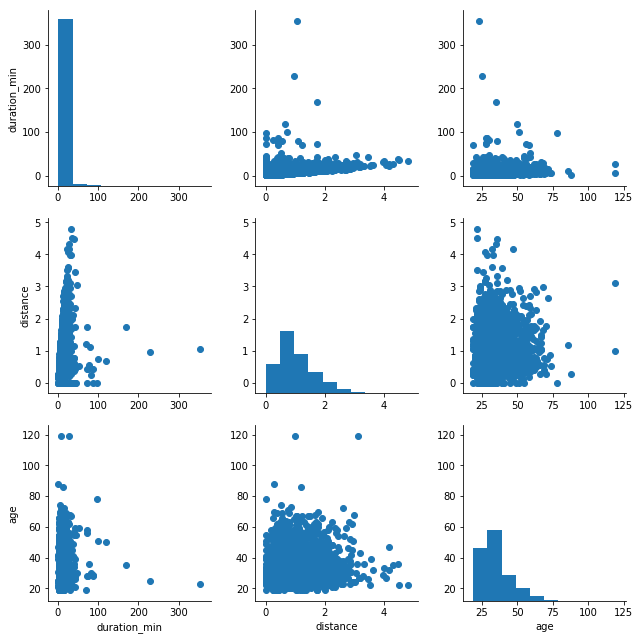

```python
df_samp = df_1.sample(n=2000, replace = False)


g = sb.PairGrid(data = df_samp, vars = ['duration_min', 'distance', 'age'], size = 3)
g = g.map_diag(plt.hist)
g.map_offdiag(plt.scatter)
```

Duration, distance and age of users don't have any strong correlation.

Next I'd like to get a plot matrix of numeric features against categorical features.

Since there are some outliers for duration_min, I'd like to focus on the range of 0 minute to 100 minutes.

```python
df_1 = df.query('duration_min < 100')
```

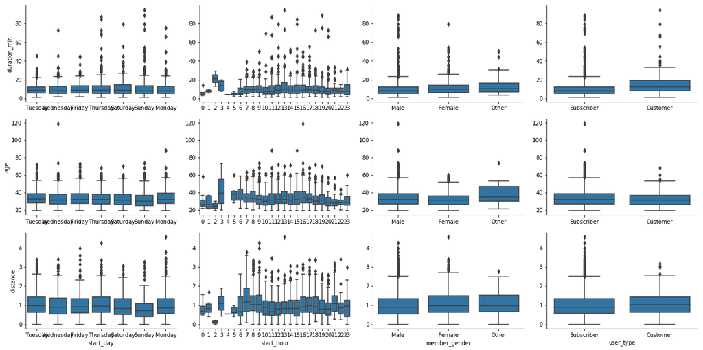

```python
# plot matrix of numeric features against categorical features.

df_samp1 = df_1.sample(n=2000, replace = False)


def boxgrid(x, y, **kwargs):
    default_color = sb.color_palette()[0]
    sb.boxplot(x=x, y=y, color=default_color)

plt.figure(figsize = [10, 10])
g = sb.PairGrid(data = df_samp1, y_vars = numeric_vars, x_vars = categoric_vars,
                size = 3, aspect = 1.5, dropna = True)
g.map(boxgrid)
plt.show();
```

As we are more interested in the difference between 'male' and 'female', I will remove the rows with 'other' gender. Subscribers have a shorter average trip duration and average trip distance than normal customers. Let's say the busy hours in the morning is 6am to 8am. Although the distance of trips from 6am to 8am is relatively longer, the duration is not relatively higher. It suggested that the riders might be riding in a faster pace during the busy hours.

Next, I'd move on to plots of categorical variables.

```python
df_2 = df.query('member_gender != "Other"')
```

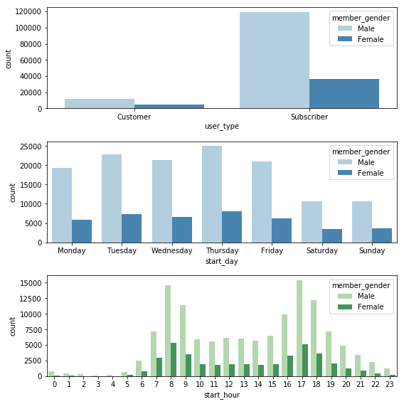

```python
# since there's only three subplots to create, using the full data should be fine.
plt.figure(figsize = [8, 8])

# subplot 1: user_type vs member_gender
plt.subplot(3, 1, 1)
sb.countplot(data = df_2, x = 'user_type', hue = 'member_gender', palette = 'Blues')

# subplot 2: start_day vs member_gender
ax = plt.subplot(3, 1, 2)
sb.countplot(data = df_2, x = 'start_day', hue = 'member_gender', order = day_order, palette = 'Blues')

# subplot 3: start_hour vs member_gender
ax = plt.subplot(3, 1, 3)
sb.countplot(data = df_2, x = 'start_hour', hue = 'member_gender', palette = 'Greens')

plt.tight_layout()

plt.show()
```

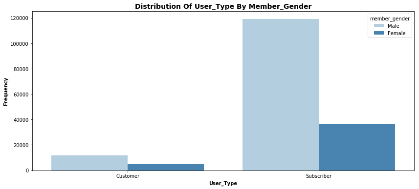

```python
# Below 3 plots are the same as the above plots, but I used the function mycountplot
mycountplot(df_2, 'user_type', hue = 'member_gender', palette = 'Blues')
```

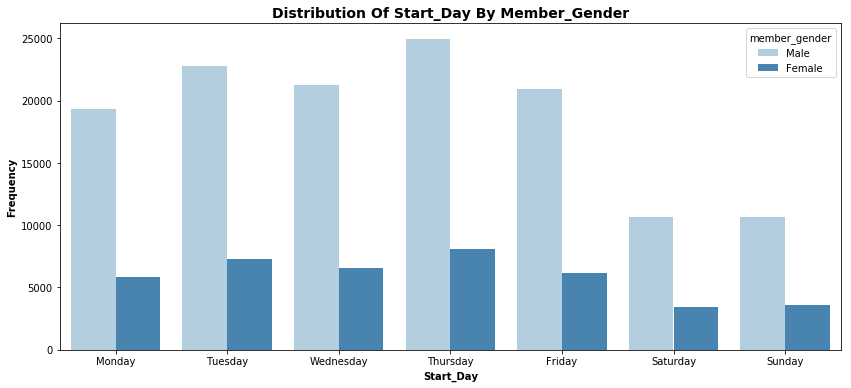

```python
mycountplot(df_2, 'start_day', hue = 'member_gender', order = day_order, palette = 'Blues')
```

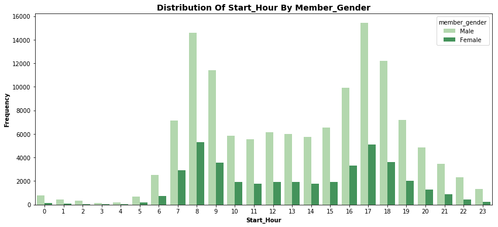

```python
mycountplot(df_2, 'start_hour', hue = 'member_gender', palette = 'Greens')
```

Most of the subscribers are male. Their activities are much more higher than females.

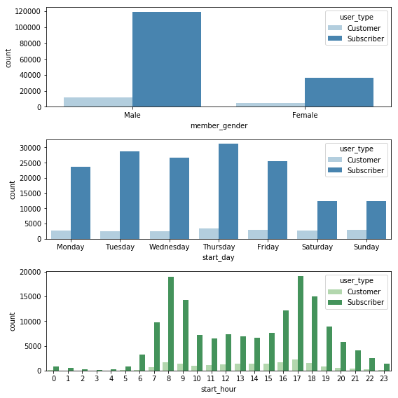

```python
# since there's only three subplots to create, using the full data should be fine.
plt.figure(figsize = [8, 8])

# subplot 1: member_gender vs user_type, this is the same as the first subplot on the previous figure
plt.subplot(3, 1, 1)
sb.countplot(data = df_2, x = 'member_gender', hue = 'user_type', palette = 'Blues')

# subplot 2: start_day vs user_type
ax = plt.subplot(3, 1, 2)
sb.countplot(data = df_2, x = 'start_day', hue = 'user_type', order = day_order, palette = 'Blues')

# subplot 3: start_hour vs user_type, use different color palette
ax = plt.subplot(3, 1, 3)
sb.countplot(data = df_2, x = 'start_hour', hue = 'user_type', palette = 'Greens')

plt.tight_layout()

plt.show()
```

Most of the users are subscribers. Their activities are much more higher than normal customers.

Next, I'd like to see how duration_min and distance are related to one another for all of the data

```python
df['duration_min'].describe()
```

```
count    183412.000000
mean         12.101301
std          29.906501
min           1.020000
25%           5.420000
50%           8.570000
75%          13.270000
max        1424.070000
Name: duration_min, dtype: float64
```

```python
df['distance'].describe()
```

```
count    183412.000000
mean          1.050462
std           0.681742
min           0.000000
25%           0.565309
50%           0.888503
75%           1.383277
max          43.164157
Name: distance, dtype: float64
```

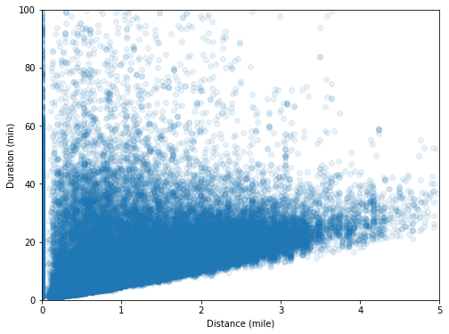

```python
# scatter plot of duration_min vs distance

plt.figure(figsize = [8, 6])
plt.scatter(data = df, x = 'distance', y = 'duration_min', alpha = 1/10)
plt.xlim([0, 5])
plt.ylim([0, 100])
plt.xlabel('Distance (mile)')
plt.ylabel('Duration (min)')
plt.show()
```

I thought there would be a strong correlation between distance and duration. However, the only conclusion I could draw is that the longer the distance (the further away from start station to end station), the less probable that the duration could be relatively short. It means that it would take a minimum amount of time to return the bike at an end station with certain amount of distance. We would only be confident in determining the minimum duration, but we could not be confident in determining the average duration.

Next, I'd move on to duration_min vs age.

```python
df['duration_min'].describe()
```

```
count    183412.000000
mean         12.101301
std          29.906501
min           1.020000
25%           5.420000
50%           8.570000
75%          13.270000
max        1424.070000
Name: duration_min, dtype: float64
```

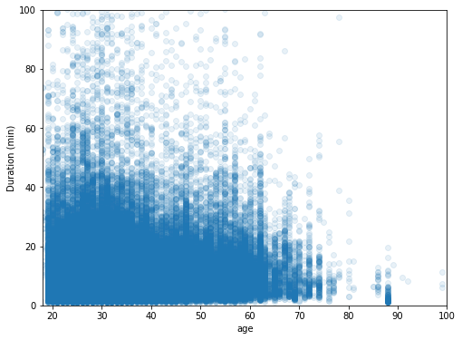

```python
# scatter plot of duration_min vs age.
plt.figure(figsize = [8, 6])
plt.scatter(data = df, x = 'age', y = 'duration_min', alpha = 1/10)
plt.xlabel('age')
# plt.yticks([1, 3, 10, 30, 100, 300], [1, 3, 10, 30, 100, 300])
plt.ylabel('Duration (min)')
plt.xlim([18, 100])
plt.ylim([0, 100])
plt.show()
```

Next I'd move on to start hour vs weekday/weekend

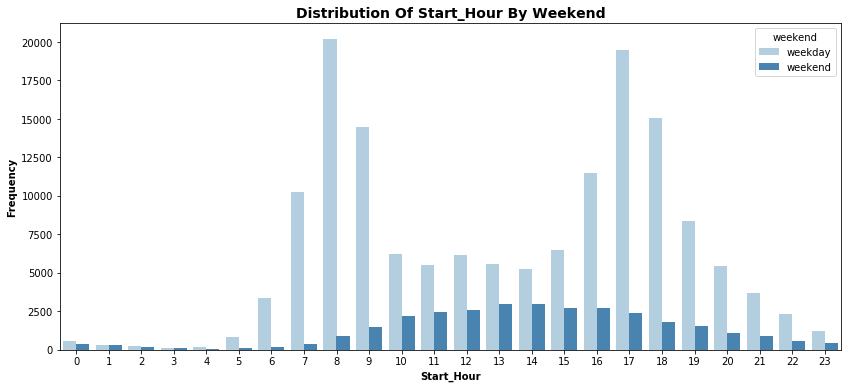

```python
mycountplot(df, 'start_hour', hue = 'weekend', palette = 'Blues')
```

For weekday, let's say the busy hours are 6am to 8am and 4pm to 7pm. There are two peaks during these two periods. But for weekend, the busy hours only start from 10am until 6pm. There is only one peak, with much less activity compared with weekdays.

### Talk about some of the relationships you observed in this part of the investigation. How did the feature(s) of interest vary with other features in the dataset?

Subscribers have a shorter average trip duration and average trip distance than normal customers.

Most of the subscribers are male. Their activities are much more higher than females.

Most of the users are subscribers. Their activities are much more higher than normal customers.

The longer the distance (the further away from start station to end station), the less probable that the duration could be relatively short. It means that it would take a minimum amount of time to return the bike at an end station with certain amount of distance. We would only be confident in determining the minimum duration, but we could not be confident in determining the average duration.

### Did you observe any interesting relationships between the other features (not the main feature(s) of interest)?

Duration, distance and age of users don't have any strong correlation.

Let's say the busy hours in the morning is 6am to 8am. Although the distance of trips from 6am to 8am is relatively longer, the duration is not relatively higher. It suggested that the riders might be riding in a faster pace during the busy hours.

## Multivariate Exploration

I would like to look at the top 10 spots people would like to start and end a bike trip on weekdays and weekends.

```python
# to use marker on a map, I'd like to use the Folium module.
!pip install folium
```

```
    100% |████████████████████████████████| 102kB 4.8MB/s a 0:00:011
```

```python
import folium
```

In the following steps, I'll create some relavant dataframes and index

```python
# to get a dataframe contains only information we are interested
stops = df[['start_station_id', 'start_station_latitude', 'start_station_longitude', 'end_station_id', 'end_station_latitude', 'end_station_longitude','start_day']]
```

```python
# to get a dataframe that contains only information about weekdays
stops_weekday = stops.query('start_day != "Saturday" and start_day != "Sunday"')
```

```python
# to get the top 10 starting spots on weekday
index_start_weekday = stops_weekday['start_station_id'].value_counts().index[:10]
```

```python
top_start_weekday = stops_weekday[stops_weekday['start_station_id'].isin(index_start_weekday)]
```

```python
# to drop the duplicates as we only need the coordinates of the station spots
top_start_weekday = top_start_weekday.drop_duplicates(subset = ['start_station_id'])
```

```python
# to get the top 10 ending spots on weekday
index_end_weekday = stops_weekday['end_station_id'].value_counts().index[:10]
```

```python
top_end_weekday = stops_weekday[stops_weekday['end_station_id'].isin(index_end_weekday)]
```

```python
# to drop the duplicates as we only need the coordinates of the station spots
top_end_weekday = top_end_weekday.drop_duplicates(subset = ['end_station_id'])
```

```python
# to get a dataframe that contains only information about weekend
stops_weekend = stops.query('start_day == "Saturday" or start_day == "Sunday"')
```

```python
# to get the top 10 starting spots on weekend
index_start_weekend = stops_weekend['start_station_id'].value_counts().index[:10]
```

```python
top_start_weekend = stops_weekend[stops_weekend['start_station_id'].isin(index_start_weekend)]
```

```python
# to drop the duplicates as we only need the coordinates of the station spots
top_start_weekend = top_start_weekend.drop_duplicates(subset = ['start_station_id'])
```

```python
# to get the top 10 ending spots on weekend
index_end_weekend = stops_weekend['end_station_id'].value_counts().index[:10]
```

```python
top_end_weekend = stops_weekend[stops_weekend['end_station_id'].isin(index_end_weekend)]
```

```python
# to drop the duplicates as we only need the coordinates of the station spots
top_end_weekend = top_end_weekend.drop_duplicates(subset = ['end_station_id'])
```

```python
# to create a map for weekday top spots
sfmap_weekday = folium.Map(location = [top_start_weekday['start_station_latitude'].mean(), top_start_weekday['start_station_longitude'].mean()], zoom_start = 12, control_scale = True)
```

```python
# to mark the top 10 starting spots on weekdays
for i, v in top_start_weekday.iterrows():
    folium.Marker(location = [v['start_station_latitude'], v['start_station_longitude']]).add_to(sfmap_weekday)
```

```python
# to mark the top 10 ending spots on weekdays
for i, v in top_end_weekday.iterrows():
    folium.Marker(location = [v['end_station_latitude'], v['end_station_longitude']]).add_to(sfmap_weekday)
```

```python
# this is the top 10 starting and top 10 ending bike trip spots on weekdays.
sfmap_weekday
```

Make this Notebook Trusted to load map: File -> Trust Notebook

[interactive chart not shown]

```python
# to create a map for weekend top spots
sfmap_weekend = folium.Map(location = [top_start_weekend['start_station_latitude'].mean(), top_start_weekend['start_station_longitude'].mean()], zoom_start = 12, control_scale = True)
```

```python
# to mark the top 10 starting spots on weekends
for i, v in top_start_weekend.iterrows():
    folium.Marker(location = [v['start_station_latitude'], v['start_station_longitude']]).add_to(sfmap_weekend)
```

```python
# to mark the top 10 ending spots on weekends
for i, v in top_end_weekend.iterrows():
    folium.Marker(location = [v['end_station_latitude'], v['end_station_longitude']]).add_to(sfmap_weekend)
```

```python
# this is the top 10 starting and top 10 ending bike trip spots on weekends.
sfmap_weekend
```

Make this Notebook Trusted to load map: File -> Trust Notebook

[interactive chart not shown]

There are some overlapping top spots when we consider the top 10 starting and top 10 ending spots on weekdays and weekends respectively. Most of them are near the San Francisco downtown.

### Talk about some of the relationships you observed in this part of the investigation. Were there features that strengthened each other in terms of looking at your feature(s) of interest?

During the weekdays, the top 10 spots would be centred around the San Francisco downton. But the top 10 spots would be slightly more spreaded for weekends.

### Were there any interesting or surprising interactions between features?

I thought the spots for weekend would be much more spreaded. But indeed there are a lot of overlapping top spots, even for weekends.

## Conclusions

This data set includes information about individual rides made in a bike-sharing system covering the greater San Francisco Bay area. I have further wrangled the data by changing the columns into the suitable data type, such as having the start_time in datetime data type. I have also added new columns like duration_min (in minutes), age of users, distance calculated by coordinates, start_hour from start_time, start day and weekend.

Here is a summary of the findings from the study:

Finding 1: Most of the riders take a ride with 5 to 15 minutes. 15 minutes would already be over 75% percentile (13 minutes).

Finding 2: 89.17% of users are subscribers, while 10.83% of them are normal customers.

Finding 3: 74.60% of the users are males, while 23.32% of them are females.

Finding 4: The average age of the users is 34.2.

Finding 5: 83.14% of users ride on weekdays.

Finding 6: There are two peaks in a day. Most users ride from 8 - 10, and 16 - 20, which are the usual time people get to work and go home.

Finding 7: Most of the rides have an average distance of 1 mile.

Finding 8: Duration, distance and age of users don't have any strong correlation.

Finding 9: Subscribers have a shorter average trip duration and average trip distance than normal customers.

Finding 11: Most of the subscribers are male. Their activities are much more higher than females.

Finding 12: Most of the users are subscribers. Their activities are much more higher than normal customers.

Finding 13: The longer the distance (the further away from start station to end station), the less probable that the duration could be relatively short. It means that it would take a minimum amount of time to return the bike at an end station with certain amount of distance. We would only be confident in determining the minimum duration, but we could not be confident in determining the average duration.

Finding 15: I have identified the top 10 starting and ending spots on weekdays and weekends respectively. Most of them are near the San Francisco downtown.